# Waste Management, Inc. (NYSE: WM) — Avance del Proyecto Final

Derivados | Emisión de bono convertible con call spread (caso Molson Coors aplicado a WM)

Equipo

Datos LSEG Workspace al 21-oct-2026 · Reporte generado 24/10/2026

# 1. Situación problema y propuesta de estrategia

**Caso base:** *Molson Coors Brewing Co.: Valuing a Convertible Bond* (Deutsche Bank, 2007). Molson emitió un convertible a 6 años (cupón 2.5%, prima 25%) y lo combinó con un **call spread** (compra de calls al 25% y venta de warrants al 60%) para elevar la prima efectiva; usó los recursos para **recomprar deuda cara** (bono 6.375% 2012).

**Propuesta para WM (hipotética):**

- Emitir **USD 750 mm** en bonos convertibles senior a **6 años** con prima de conversión de **25%**.
- Usar los recursos para recomprar sus 3 bonos de cupón más alto: **7.00% 2028, 7.75% 2032 y 6.125% 2039** (USD 647 mm nominales).
- Comprar un *note hedge* (calls al 25%) y vender *warrants* al 60% → **prima efectiva de 60%**.
- Preguntas a resolver: ¿qué cupón deja el convertible a la par? ¿cuánto cuesta el call spread? ¿le conviene a WM?

# 2. Overview de la empresa

```r
precio  <- 229.58      # Official close 21-oct-2026 (Price Performance)
mktcap  <- 91767       # USD mm (Overview - Capital Structure)
acciones <- mktcap / precio
```

Precio de cierre  
**$229.58**  
21-oct-2026

Market cap  
**$91.8 bn**  
399.7 mm acciones

Enterprise value  
**$114.6 bn**  
EV/EBITDA LTM 14.6x

Calificación  
**A- / A-**  
S&P / Fitch

**Descripción (LSEG):** Waste Management, Inc. es proveedor de soluciones ambientales en EE.UU. y Canadá: recolección, reciclaje y disposición de residuos. Segmentos: *East Tier, West Tier, Recycling Processing and Sales, WM Renewable Energy* y *WM Healthcare Solutions* (residuos regulados y destrucción segura de información). Sector TRBC: *Environmental Services & Equipment*.

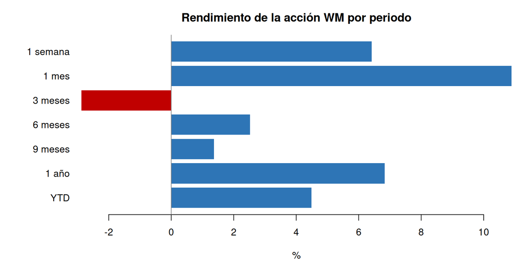

```r
desempeno <- data.frame(
  Periodo = c("1 semana", "1 mes", "3 meses", "6 meses", "9 meses", "1 año", "YTD"),
  Rendimiento = c(6.4121, 10.8868, -2.8766, 2.5231, 1.3643, 6.8361, 4.4923) / 100
)
mercado <- data.frame(
  Concepto = c("Máximo 52 semanas", "Mínimo 52 semanas", "Vol. histórica 10d", "Vol. histórica 30d",
               "Vol. histórica 90d", "Vol. histórica 200d", "Beta 2 años", "Beta 5 años",
               "Dividend yield bruto", "Precio / valor en libros", "Volumen promedio 30d"),
  Valor = c("$248.10 (06-mar-2026)", "$194.15 (03-nov-2025)", "21.74%", "19.76%", "21.04%", "20.71%",
            "-0.07", "0.41", "1.63%", "9.25x", "671,734")
)
par(mar = c(4, 7, 3, 1))
barplot(rev(desempeno$Rendimiento) * 100, names.arg = rev(desempeno$Periodo), horiz = TRUE, las = 1,
        col = ifelse(rev(desempeno$Rendimiento) >= 0, azul2, rojo), border = NA,
        xlab = "%", main = "Rendimiento de la acción WM por periodo")
abline(v = 0, col = gris)
```

```r
tabla(mercado, "Indicadores de mercado (LSEG: Price Performance)")
```

Indicadores de mercado (LSEG: Price Performance)

| Concepto | Valor |
| --- | --- |
| Máximo 52 semanas | $248.10 (06-mar-2026) |
| Mínimo 52 semanas | $194.15 (03-nov-2025) |
| Vol. histórica 10d | 21.74% |
| Vol. histórica 30d | 19.76% |
| Vol. histórica 90d | 21.04% |
| Vol. histórica 200d | 20.71% |
| Beta 2 años | -0.07 |
| Beta 5 años | 0.41 |
| Dividend yield bruto | 1.63% |
| Precio / valor en libros | 9.25x |
| Volumen promedio 30d | 671,734 |

**Lectura:** WM es una acción defensiva (beta a 5 años de 0.41) con volatilidad histórica de ~20-21%. Para la opción de conversión eso implica un valor moderado, y un cupón del convertible bajo pero no extremo.

# 3. Análisis financiero y ratios

```r
ratios <- data.frame(
  Ratio = c("EV / Revenue", "EV / EBITDA", "EV / EBIT", "Deuda total / EV", "Deuda total / EBITDA",
            "EBITDA / Intereses", "(EBITDA - Capex) / Intereses", "EBIT / Intereses", "P / U",
            "Dividend yield (%)", "FOCF yield (%)", "Precio / Ventas", "Precio / Flujo"),
  LTM_jun26 = c(4.46, 14.61, 23.72, 0.20, 2.98, 8.65, 5.09, 5.33, 32.50, 1.54, 3.89, 3.61, 14.23),
  FY2024 = c(4.74, 16.28, 25.18, 0.23, 3.73, 10.73, 5.33, 6.94, 29.64, 1.52, 2.67, 3.69, 15.10),
  FY2025 = c(4.41, 14.89, 24.14, 0.21, 3.07, 8.19, 4.65, 5.05, 32.79, 1.13, 3.18, 3.52, 14.70),
  FY2026e = c(4.34, 13.97, 22.47, NA, 2.85, 8.89, 6.01, 5.53, 28.24, 1.63, 4.14, 3.47, 14.90),
  FY2027e = c(4.12, 13.06, 20.53, NA, 2.66, 9.54, 6.43, 6.07, 25.31, 1.73, 4.53, 3.30, 13.79),
  FY2028e = c(3.94, 12.32, 19.08, NA, 2.51, 10.60, 7.21, 6.84, 23.14, 1.82, 4.85, 3.15, 12.07)
)
tabla(ratios, "Key Ratios — históricos y consenso (media) LSEG")
```

Key Ratios — históricos y consenso (media) LSEG

| Ratio | LTM_jun26 | FY2024 | FY2025 | FY2026e | FY2027e | FY2028e |
| --- | --- | --- | --- | --- | --- | --- |
| EV / Revenue | 4.46 | 4.74 | 4.41 | 4.34 | 4.12 | 3.94 |
| EV / EBITDA | 14.61 | 16.28 | 14.89 | 13.97 | 13.06 | 12.32 |
| EV / EBIT | 23.72 | 25.18 | 24.14 | 22.47 | 20.53 | 19.08 |
| Deuda total / EV | 0.20 | 0.23 | 0.21 | NA | NA | NA |
| Deuda total / EBITDA | 2.98 | 3.73 | 3.07 | 2.85 | 2.66 | 2.51 |
| EBITDA / Intereses | 8.65 | 10.73 | 8.19 | 8.89 | 9.54 | 10.60 |
| (EBITDA - Capex) / Intereses | 5.09 | 5.33 | 4.65 | 6.01 | 6.43 | 7.21 |
| EBIT / Intereses | 5.33 | 6.94 | 5.05 | 5.53 | 6.07 | 6.84 |
| P / U | 32.50 | 29.64 | 32.79 | 28.24 | 25.31 | 23.14 |
| Dividend yield (%) | 1.54 | 1.52 | 1.13 | 1.63 | 1.73 | 1.82 |
| FOCF yield (%) | 3.89 | 2.67 | 3.18 | 4.14 | 4.53 | 4.85 |
| Precio / Ventas | 3.61 | 3.69 | 3.52 | 3.47 | 3.30 | 3.15 |
| Precio / Flujo | 14.23 | 15.10 | 14.70 | 14.90 | 13.79 | 12.07 |

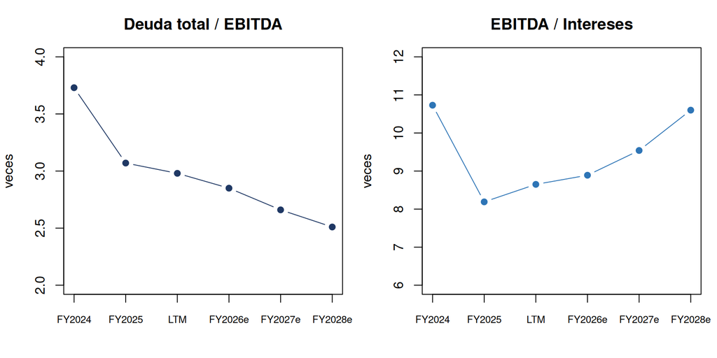

```r
anios <- c("FY2024", "FY2025", "LTM", "FY2026e", "FY2027e", "FY2028e")
apal  <- c(3.73, 3.07, 2.98, 2.85, 2.66, 2.51)
cobert <- c(10.73, 8.19, 8.65, 8.89, 9.54, 10.60)
par(mfrow = c(1, 2), mar = c(4, 4, 3, 1))
plot(apal, type = "b", pch = 19, col = azul, xaxt = "n", ylim = c(2, 4), xlab = "",
     ylab = "veces", main = "Deuda total / EBITDA"); axis(1, 1:6, anios, cex.axis = 0.75)
plot(cobert, type = "b", pch = 19, col = azul2, xaxt = "n", ylim = c(6, 12), xlab = "",
     ylab = "veces", main = "EBITDA / Intereses"); axis(1, 1:6, anios, cex.axis = 0.75)
```

```r
par(mfrow = c(1, 1))
```

**Lectura:** el apalancamiento subió en 2024 (adquisición de Stericycle → *WM Healthcare Solutions*) y el consenso espera desapalancamiento a 2.5x en 2028. La cobertura de intereses es holgada (8.7x), consistente con la calificación A-. Reducir el gasto por intereses con el convertible acelera ese desapalancamiento.

# 4. Estructura de capital y deuda

## Estructura de capital

```r
capital <- data.frame(
  Concepto = c("Market cap", "(-) Efectivo y equivalentes", "(+) Deuda total", "(+) Interés minoritario",
               "= Enterprise value", "Capital contable", "Capital total (deuda + capital contable)",
               "Deuda / Capital contable", "Deuda / Capital total"),
  Valor = c("$91,767", "$557", "$23,356", "$1", "$114,567", "$9,925", "$33,282", "235.33%", "70.18%")
)
tabla(capital, "USD millones · financieros al 30-jun-2026 (LSEG Overview)")
```

USD millones · financieros al 30-jun-2026 (LSEG Overview)

| Concepto | Valor |
| --- | --- |
| Market cap | $91,767 |
| (-) Efectivo y equivalentes | $557 |
| (+) Deuda total | $23,356 |
| (+) Interés minoritario | $1 |
| = Enterprise value | $114,567 |
| Capital contable | $9,925 |
| Capital total (deuda + capital contable) | $33,282 |
| Deuda / Capital contable | 235.33% |
| Deuda / Capital total | 70.18% |

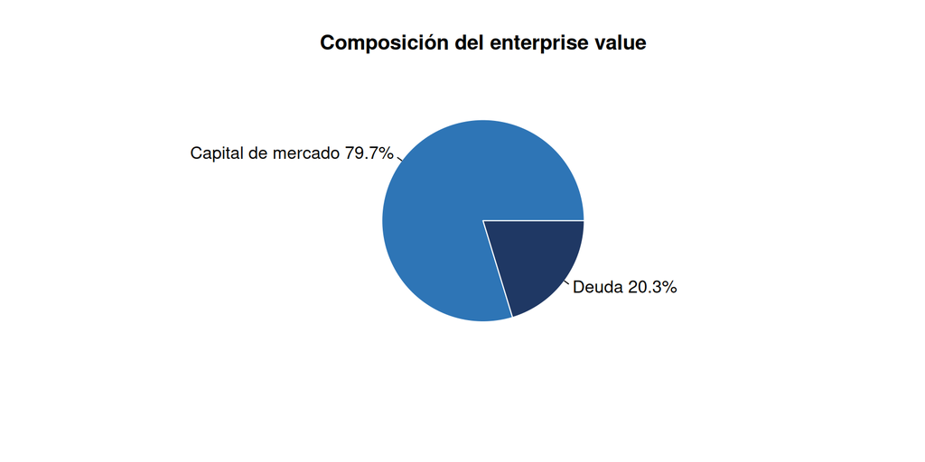

```r
pie(c(91767, 23356), labels = c("Capital de mercado 79.7%", "Deuda 20.3%"),
    col = c(azul2, azul), border = "white", main = "Composición del enterprise value")
```

## Perfil de deuda

```r
estructura <- data.frame(
  Instrumento = c("Bonos vigentes", "Préstamos (línea de crédito)", "Total", "Bonos inactivos (históricos)"),
  Emisiones = c(40, 1, 41, 1272),
  Monto_vigente_USD = c(17948298006, NA, 17948298006, NA),
  Monto_emitido_USD = c(21191891006, 3500000000, 24691891006, 28775591576)
)
tabla(estructura, "Debt Structure (DS) — LSEG")
```

Debt Structure (DS) — LSEG

| Instrumento | Emisiones | Monto_vigente_USD | Monto_emitido_USD |
| --- | --- | --- | --- |
| Bonos vigentes | 40 | 17,948,298,006 | 21,191,891,006 |
| Préstamos (línea de crédito) | 1 | NA | 3,500,000,000 |
| Total | 41 | 17,948,298,006 | 24,691,891,006 |
| Bonos inactivos (históricos) | 1,272 | NA | 28,775,591,576 |

```r
moneda <- data.frame(Moneda = c("Dólar estadounidense", "Dólar canadiense"),
                     Emisiones = c(39, 1), Vigente_USD_mm = c(17449.9, 498.4))
moneda$Participacion <- pct(moneda$Vigente_USD_mm / sum(moneda$Vigente_USD_mm), 1)
tabla(moneda, "Bonos por moneda")
```

Bonos por moneda

| Moneda | Emisiones | Vigente_USD_mm | Participacion |
| --- | --- | --- | --- |
| Dólar estadounidense | 39 | 17,449.9 | 97.2% |
| Dólar canadiense | 1 | 498.4 | 2.8% |

La deuda es casi 100% en dólares (97.2%), de tasa fija y senior no garantizada: el riesgo cambiario es marginal (solo un bono en CAD) y el riesgo relevante es de **tasa de interés y refinanciamiento**.

## Bonos de WM en el mercado

```r
bonos <- data.frame(
  Cupon = c(7.00, 3.88, 4.88, 2.00, 4.63, 4.65, 1.50, 4.95, 4.80, 4.15, 7.75, 4.63, 4.88, 3.90,
            4.95, 6.13, 2.95, 4.10, 4.15, 2.50, 5.35),
  Vencimiento = as.Date(c("2028-07-15", "2029-01-15", "2029-02-15", "2029-06-01", "2030-02-15",
                          "2030-03-15", "2031-03-15", "2031-07-03", "2032-03-15", "2032-04-15",
                          "2032-05-15", "2033-02-15", "2034-02-15", "2035-03-01", "2035-03-15",
                          "2039-11-30", "2041-06-01", "2045-03-01", "2049-07-15", "2050-11-15",
                          "2054-10-15")),
  Precio_ask = c(102.833, 97.345, 99.433, 92.324, 98.040, 98.188, 85.162, 98.428, 97.176, 94.218,
                 108.825, 95.615, 96.216, 87.847, 95.478, 102.300, 70.970, 78.956, 76.100, 55.807, 90.737),
  YTM_ask = c(5.256, 5.149, 5.135, 5.187, 5.276, 5.238, 5.332, 5.331, 5.409, 5.383, 5.866, 5.454,
              5.509, 5.751, 5.633, 5.870, 5.953, 6.007, 6.108, 5.991, 6.040),
  Spread_bmk_pb = c(52.1, 40.2, 38.7, 35.5, 44.7, 41.0, 44.9, 44.9, 52.8, 50.2, 97.5, 49.4, 55.0,
                    78.2, 57.6, 81.4, 89.4, 60.4, 70.2, 58.4, 68.9)
)
bonos$Plazo_anios <- round(as.numeric(bonos$Vencimiento - as.Date("2026-10-21")) / 365.25, 1)
tabla(bonos, "Bonos constituyentes de la curva del emisor (Issuer Curve, cotización 21-oct-2026)")
```

Bonos constituyentes de la curva del emisor (Issuer Curve, cotización 21-oct-2026)

| Cupon | Vencimiento | Precio_ask | YTM_ask | Spread_bmk_pb | Plazo_anios |
| --- | --- | --- | --- | --- | --- |
| 7.00 | 2028-07-15 | 102.833 | 5.256 | 52.1 | 1.7 |
| 3.88 | 2029-01-15 | 97.345 | 5.149 | 40.2 | 2.2 |
| 4.88 | 2029-02-15 | 99.433 | 5.135 | 38.7 | 2.3 |
| 2.00 | 2029-06-01 | 92.324 | 5.187 | 35.5 | 2.6 |
| 4.63 | 2030-02-15 | 98.040 | 5.276 | 44.7 | 3.3 |
| 4.65 | 2030-03-15 | 98.188 | 5.238 | 41.0 | 3.4 |
| 1.50 | 2031-03-15 | 85.162 | 5.332 | 44.9 | 4.4 |
| 4.95 | 2031-07-03 | 98.428 | 5.331 | 44.9 | 4.7 |
| 4.80 | 2032-03-15 | 97.176 | 5.409 | 52.8 | 5.4 |
| 4.15 | 2032-04-15 | 94.218 | 5.383 | 50.2 | 5.5 |
| 7.75 | 2032-05-15 | 108.825 | 5.866 | 97.5 | 5.6 |
| 4.63 | 2033-02-15 | 95.615 | 5.454 | 49.4 | 6.3 |
| 4.88 | 2034-02-15 | 96.216 | 5.509 | 55.0 | 7.3 |
| 3.90 | 2035-03-01 | 87.847 | 5.751 | 78.2 | 8.4 |
| 4.95 | 2035-03-15 | 95.478 | 5.633 | 57.6 | 8.4 |
| 6.13 | 2039-11-30 | 102.300 | 5.870 | 81.4 | 13.1 |
| 2.95 | 2041-06-01 | 70.970 | 5.953 | 89.4 | 14.6 |
| 4.10 | 2045-03-01 | 78.956 | 6.007 | 60.4 | 18.4 |
| 4.15 | 2049-07-15 | 76.100 | 6.108 | 70.2 | 22.7 |
| 2.50 | 2050-11-15 | 55.807 | 5.991 | 58.4 | 24.1 |
| 5.35 | 2054-10-15 | 90.737 | 6.040 | 68.9 | 28.0 |

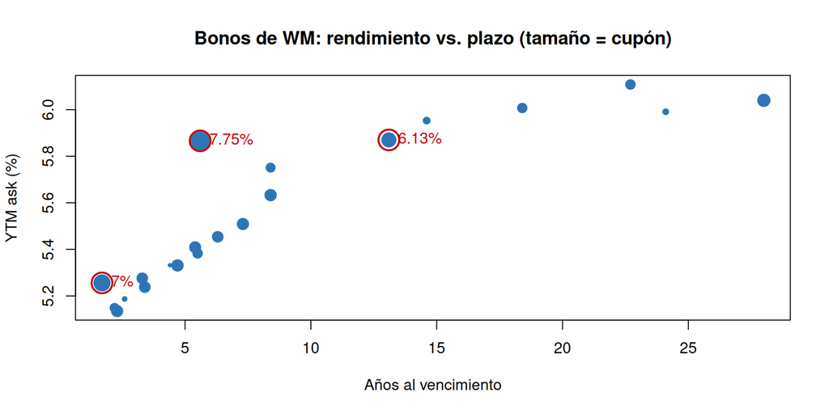

```r
plot(bonos$Plazo_anios, bonos$YTM_ask, pch = 19, cex = bonos$Cupon / 3, col = azul2,
     xlab = "Años al vencimiento", ylab = "YTM ask (%)",
     main = "Bonos de WM: rendimiento vs. plazo (tamaño = cupón)")
alto <- bonos$Cupon >= 6
points(bonos$Plazo_anios[alto], bonos$YTM_ask[alto], pch = 1, cex = 3, col = rojo, lwd = 2)
text(bonos$Plazo_anios[alto], bonos$YTM_ask[alto], paste0(bonos$Cupon[alto], "%"), pos = 4, col = rojo)
```

## Bonos a recomprar

```r
recompra <- data.frame(
  Bono = c("WM 7.00% 15-jul-2028", "WM 7.75% 15-may-2032", "WM 6.125% 30-nov-2039"),
  ISIN = c("US902917AH67", "US94106LAN91", "US94106LAV18"),
  Cupon = c(0.07, 0.0775, 0.06125),
  Nominal_mm = c(257.907, 143.621, 245.686),
  Precio_ask = c(102.8405, 108.8381, 102.2998),
  Prima_tender = 1
)
recompra$Costo_tender_mm <- recompra$Nominal_mm * (recompra$Precio_ask + recompra$Prima_tender) / 100
recompra$Cupon_anual_mm  <- recompra$Nominal_mm * recompra$Cupon
tabla(recompra, "Candidatos a recompra (montos vigentes: páginas de cada bono en LSEG)")
```

Candidatos a recompra (montos vigentes: páginas de cada bono en LSEG)

| Bono | ISIN | Cupon | Nominal_mm | Precio_ask | Prima_tender | Costo_tender_mm | Cupon_anual_mm |
| --- | --- | --- | --- | --- | --- | --- | --- |
| WM 7.00% 15-jul-2028 | US902917AH67 | 0.07000 | 257.907 | 102.8405 | 1 | 267.8119 | 18.05349 |
| WM 7.75% 15-may-2032 | US94106LAN91 | 0.07750 | 143.621 | 108.8381 | 1 | 157.7506 | 11.13063 |
| WM 6.125% 30-nov-2039 | US94106LAV18 | 0.06125 | 245.686 | 102.2998 | 1 | 253.7931 | 15.04827 |

```r
cat("Nominal total:", usd(sum(recompra$Nominal_mm), 1), "mm | Costo del tender:",
    usd(sum(recompra$Costo_tender_mm), 1), "mm | Cupón anual que se elimina:",
    usd(sum(recompra$Cupon_anual_mm), 1), "mm | Cupón promedio:",
    pct(sum(recompra$Cupon_anual_mm) / sum(recompra$Nominal_mm)), "\n")
```

```
## Nominal total: $647.2 mm | Costo del tender: $679.4 mm | Cupón anual que se elimina: $44.2 mm | Cupón promedio: 6.83%
```

# 5. Calificación y riesgo de crédito

## Calificaciones

```r
calif <- data.frame(
  Agencia = c("S&P (emisor, largo plazo)", "Fitch (emisor, largo plazo)", "Moody's",
              "Calificación de emisión (bonos senior)"),
  Calificacion = c("A-", "A-", "WR (retirada)", "BBB"),
  Fecha = c("04-jun-2024", "13-ago-2026", "07-may-2018", "17-ago-2026 (EGJ)"),
  Comentario = c("Grado de inversión", "Grado de inversión", "Sin calificación vigente",
                 "Reportada en la pantalla de cada bono")
)
tabla(calif, "Calificaciones crediticias (LSEG: Bond Ratings / Issuer Ratings)")
```

Calificaciones crediticias (LSEG: Bond Ratings / Issuer Ratings)

| Agencia | Calificacion | Fecha | Comentario |
| --- | --- | --- | --- |
| S&P (emisor, largo plazo) | A- | 04-jun-2024 | Grado de inversión |
| Fitch (emisor, largo plazo) | A- | 13-ago-2026 | Grado de inversión |
| Moody’s | WR (retirada) | 07-may-2018 | Sin calificación vigente |
| Calificación de emisión (bonos senior) | BBB | 17-ago-2026 (EGJ) | Reportada en la pantalla de cada bono |

Un emisor **A-** con cobertura de intereses de 8.7x tiene acceso amplio al mercado; por eso el convertible se valúa descontando el bono directo a la curva de WM (spread ~66 pb sobre Treasuries a 6 años) y no a una tasa high-yield.

## Curva del emisor y probabilidad de incumplimiento

```r
curva <- data.frame(
  Plazo = c(1, 2, 3, 4, 5, 6, 7, 8, 9, 10, 12, 15, 20, 25, 30),
  Yield = c(5.363, 5.292, 5.350, 5.454, 5.559, 5.649, 5.722, 5.783, 5.838, 5.886, 5.967, 6.060, 6.145, 6.170, 6.164),
  Spread_bmk = c(88.3, 48.6, 46.1, 52.9, 60.9, 65.7, 69.3, 72.0, 74.5, 76.8, 76.8, 73.8, 67.9, 71.7, 75.5),
  Z_spread = c(97.1, 74.9, 79.1, 91.0, 102.6, 111.9, 118.8, 124.1, 128.3, 131.5, 135.9, 140.3, 145.8, 150.8, 154.8),
  Prob_default = c(0.864, 1.276, 2.086, 3.359, 4.893, 6.465, 8.109, 9.746, 11.332, 12.866, 15.817, 20.136, 27.367, 35.026, 42.755)
)
curva$Treasury <- curva$Yield - curva$Spread_bmk / 100
tabla(curva, "Issuer Curve 0#WMUSDABMK= (yield %, spreads en pb, probabilidad de default acumulada %)")
```

Issuer Curve 0#WMUSDABMK= (yield %, spreads en pb, probabilidad de default acumulada %)

| Plazo | Yield | Spread_bmk | Z_spread | Prob_default | Treasury |
| --- | --- | --- | --- | --- | --- |
| 1 | 5.363 | 88.3 | 97.1 | 0.864 | 4.480 |
| 2 | 5.292 | 48.6 | 74.9 | 1.276 | 4.806 |
| 3 | 5.350 | 46.1 | 79.1 | 2.086 | 4.889 |
| 4 | 5.454 | 52.9 | 91.0 | 3.359 | 4.925 |
| 5 | 5.559 | 60.9 | 102.6 | 4.893 | 4.950 |
| 6 | 5.649 | 65.7 | 111.9 | 6.465 | 4.992 |
| 7 | 5.722 | 69.3 | 118.8 | 8.109 | 5.029 |
| 8 | 5.783 | 72.0 | 124.1 | 9.746 | 5.063 |
| 9 | 5.838 | 74.5 | 128.3 | 11.332 | 5.093 |
| 10 | 5.886 | 76.8 | 131.5 | 12.866 | 5.118 |
| 12 | 5.967 | 76.8 | 135.9 | 15.817 | 5.199 |
| 15 | 6.060 | 73.8 | 140.3 | 20.136 | 5.322 |
| 20 | 6.145 | 67.9 | 145.8 | 27.367 | 5.466 |
| 25 | 6.170 | 71.7 | 150.8 | 35.026 | 5.453 |
| 30 | 6.164 | 75.5 | 154.8 | 42.755 | 5.409 |

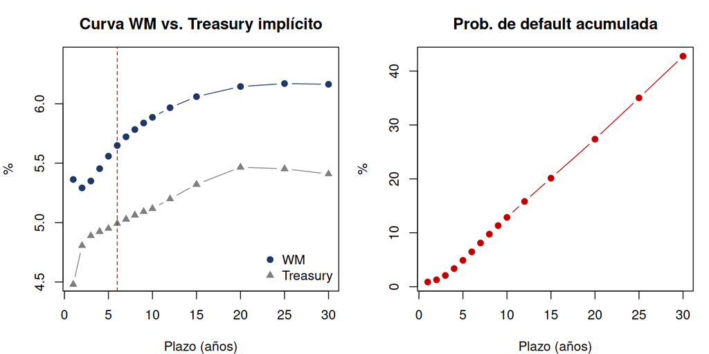

```r
par(mfrow = c(1, 2), mar = c(4, 4, 3, 1))
plot(curva$Plazo, curva$Yield, type = "b", pch = 19, col = azul, ylim = c(4.5, 6.4),
     xlab = "Plazo (años)", ylab = "%", main = "Curva WM vs. Treasury implícito")
lines(curva$Plazo, curva$Treasury, type = "b", pch = 17, col = gris)
abline(v = 6, lty = 2, col = rojo)
legend("bottomright", c("WM", "Treasury"), col = c(azul, gris), pch = c(19, 17), bty = "n")
plot(curva$Plazo, curva$Prob_default, type = "b", pch = 19, col = rojo,
     xlab = "Plazo (años)", ylab = "%", main = "Prob. de default acumulada")
```

```r
par(mfrow = c(1, 1))
```

A 6 años (plazo del convertible): rendimiento de **5.649%**, spread de **65.7 pb** y probabilidad de incumplimiento acumulada de **6.5%** implícita en precios de mercado.

# 6. Tasas y volatilidad (insumos de la valuación)

## Tasas

```r
ust5 <- 0.049182; ust7 <- 0.049954; rf <- (ust5 + ust7) / 2; y_wm <- 0.05649
tabla(data.frame(
  Insumo = c("Treasury 5 años (US5YT=RR)", "Treasury 7 años (US7YT=RR)",
             "Tasa libre de riesgo 6 años (interpolada)", "Tasa de descuento: YTM WM 6 años"),
  Valor = c(pct(ust5, 3), pct(ust7, 3), pct(rf, 3), pct(y_wm, 3))), "Tasas de mercado al 21-oct-2026")
```

Tasas de mercado al 21-oct-2026

| Insumo | Valor |
| --- | --- |
| Treasury 5 años (US5YT=RR) | 4.918% |
| Treasury 7 años (US7YT=RR) | 4.995% |
| Tasa libre de riesgo 6 años (interpolada) | 4.957% |
| Tasa de descuento: YTM WM 6 años | 5.649% |

## Volatilidad implícita

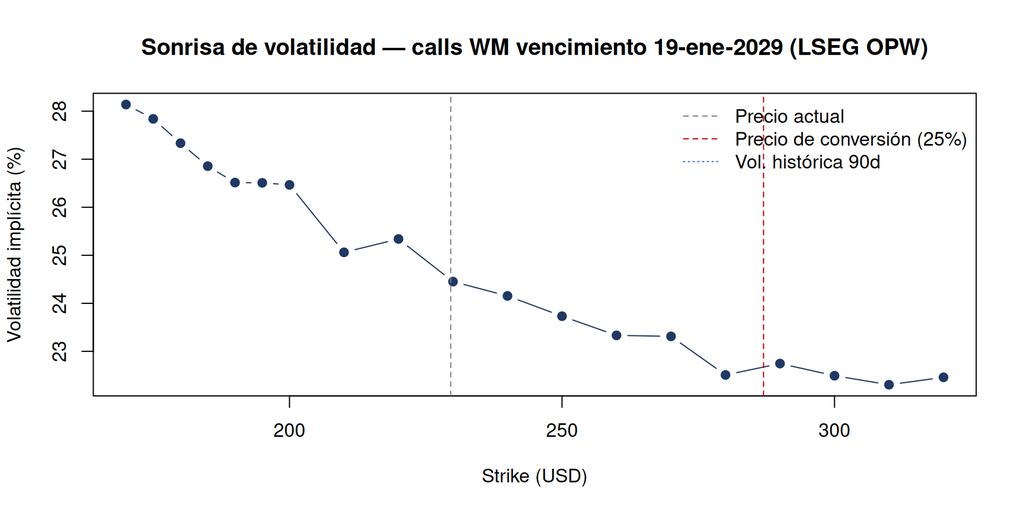

```r
iv <- data.frame(
  Strike = c(170, 175, 180, 185, 190, 195, 200, 210, 220, 230, 240, 250, 260, 270, 280, 290, 300, 310, 320),
  IV = c(28.1390, 27.8401, 27.3338, 26.8558, 26.5135, 26.5080, 26.4654, 25.0615, 25.3394, 24.4515,
         24.1535, 23.7319, 23.3327, 23.3120, 22.5082, 22.7453, 22.4926, 22.3048, 22.4595),
  Delta = c(0.8592, 0.8456, 0.8305, 0.8149, 0.7983, 0.7800, 0.7609, 0.7242, 0.6813, 0.6380, 0.5927,
            0.5470, 0.5006, 0.4561, 0.4089, 0.3704, 0.3305, 0.2941, 0.2624)
)
plot(iv$Strike, iv$IV, type = "b", pch = 19, col = azul,
     xlab = "Strike (USD)", ylab = "Volatilidad implícita (%)",
     main = "Sonrisa de volatilidad — calls WM vencimiento 19-ene-2029 (LSEG OPW)")
abline(v = c(precio, precio * 1.25), lty = 2, col = c(gris, rojo))
abline(h = 21.04, lty = 3, col = azul2)
legend("topright", c("Precio actual", "Precio de conversión (25%)", "Vol. histórica 90d"),
       col = c(gris, rojo, azul2), lty = c(2, 2, 3), bty = "n")
```

El LEAPS más largo vence en ene-2029. Para la opción de conversión usamos la vol. implícita del strike 290 (≈ precio de conversión): **22.75%**. Para el warrant usamos la histórica de 90 días (**21.04%**), siguiendo al caso, que valúa el warrant con una volatilidad menor (21% vs. 23%).

# 7. Valuación preliminar del convertible

```r
bs_call <- function(S, K, r, s, T, q = 0) {
  d1 <- (log(S / K) + (r - q + s^2 / 2) * T) / (s * sqrt(T)); d2 <- d1 - s * sqrt(T)
  c(precio = S * exp(-q * T) * pnorm(d1) - K * exp(-r * T) * pnorm(d2), delta = exp(-q * T) * pnorm(d1))
}
valor_bono <- function(cup, y = y_wm, F = 1000, T = 6, m = 2) {
  t <- 1:(T * m); cf <- rep(F * cup / m, T * m); cf[T * m] <- cf[T * m] + F
  sum(cf / (1 + y / m)^t)
}
monto <- 750; Tm <- 6; s_c <- 0.227453; s_w <- 0.2104
K  <- precio * 1.25; n <- 1000 / K; Kw <- precio * 1.60
call   <- bs_call(precio, K, rf, s_c, Tm)
opcion <- call["precio"] * n
cupon  <- uniroot(function(c) valor_bono(c) - (1000 - opcion), c(0, 0.1), tol = 1e-12)$root
acc_mm <- monto / K
hedge  <- call["precio"] * acc_mm
warr   <- bs_call(precio, Kw, rf, s_w, Tm)["precio"] * acc_mm

res <- data.frame(
  Concepto = c("Precio de conversión (prima 25%)", "Acciones por bono", "Call por acción (Black-Scholes)",
               "Delta", "Opción de conversión por bono", "Bono directo por bono",
               "Cupón que deja el convertible a la par", "Ahorro vs. bono directo WM (pb)",
               "Costo note hedge (USD mm)", "Ingreso warrants al 60% (USD mm)",
               "Costo neto call spread (USD mm)", "Costo neto / principal"),
  Valor = c(usd(K, 2), round(n, 4), usd(call["precio"], 2), round(call["delta"], 2),
            usd(opcion, 2), usd(1000 - opcion, 2), pct(cupon, 3), round((y_wm - cupon) * 1e4),
            usd(hedge, 1), usd(warr, 1), usd(warr - hedge, 1), pct((warr - hedge) / monto, 1))
)
tabla(res, "Resultados preliminares (Exhibits 2-4 del caso, aplicados a WM)")
```

Resultados preliminares (Exhibits 2-4 del caso, aplicados a WM)

[output not shown]

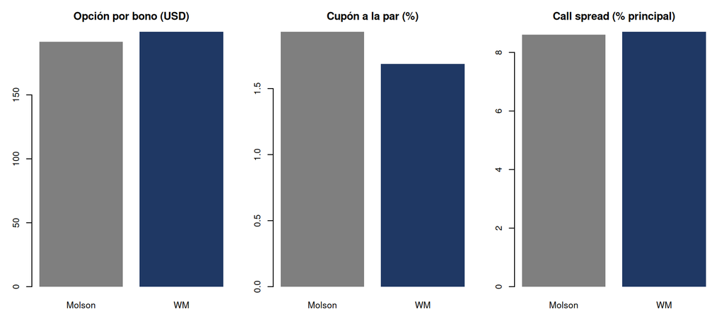

```r
comp <- rbind(Molson = c(191.5, 1.93, 8.6), WM = c(opcion, cupon * 100, -(warr - hedge) / monto * 100))
colnames(comp) <- c("Opción por bono (USD)", "Cupón a la par (%)", "Call spread (% principal)")
par(mfrow = c(1, 3), mar = c(3, 3, 3, 1))
for (j in 1:3) barplot(comp[, j], col = c(gris, azul), border = NA, main = colnames(comp)[j])
```

```r
par(mfrow = c(1, 1))
```

**Lectura preliminar:** los resultados de WM son muy parecidos a los del caso (cupón ~1.7% vs. 1.93%; call spread 8.7% vs. 8.6%). Con el convertible WM se financia ~396 pb por debajo de su deuda directa y elimina cupones de 6.83% promedio: un ahorro de ~USD 32 mm anuales antes de impuestos.

# 8. Próximos pasos

- Árbol binomial (CRR) para la opción de conversión y convergencia a Black-Scholes.
- Valuación del convertible completo en el árbol (conversión anticipada, efecto del dividendo de 1.6%).
- Comparación con pares (Republic Services, Waste Connections) en spreads y múltiplos.
- Sensibilidades: cupón vs. prima de conversión y vs. volatilidad; recomendación final al CEO.

Fuentes: LSEG Workspace (Refinitiv) — Overview, Price Performance, Key Ratios, Debt Structure, Issuer Curve, Bond Ratings, Options (OPW), US5YT=RR, US7YT=RR; caso “Molson Coors Brewing Co.: Valuing a Convertible Bond” (Tec de Monterrey, NE90-06-107). Datos al cierre del 21-oct-2026.